# TakeHomeExam

Matthias Brunner

Januar 2017

# 22 Take-Home-Exam:

Liste die in diesem Script verwendete Libraries

```r
# Hinzufuegen von Library
library(foreign)
library(dplyr)
library(data.table)
library(magrittr)
library(ggplot2)
library(stringr)
library(broom)
library(xlsx)
library(stargazer)
library(rvest)
```

## 22.1 Ebay-Auktionen

1. Laden Sie die Daten http://www.farys.org/daten/ebay.dta. Es handelt sich um Ebaydaten von Mobiltelefonauktionen.

```r
ebay <- read.dta("http://www.farys.org/daten/ebay.dta")

# Betrachten der Daten
head(ebay)
```

```
##   sold  price             subcat sprice                  listpic listbold
## 1    1 221.00     Nokia 6230 (3)      1 auction-has-picture icon        0
## 2    1 211.00  Samsung E700 (12)      1                thumbnail        0
## 3    1 221.00 Motorola V600 (10)    200 auction-has-picture icon        0
## 4    1 251.51  Samsung E800 (11)      1                     none        0
## 5    1  76.00      Sony T610 (1)      1                     none        0
## 6    1 243.00  Samsung E800 (11)      1 auction-has-picture icon        0
##   sepos seneg sehasme
## 1   372     5       0
## 2   153     0       0
## 3    20     0       0
## 4    11     0       0
## 5    16     0       0
## 6    81     1       1
```

- Speichern der Daten in Excel um Levels zu überprüfen!

```r
# write.xlsx(ebay, "c:/temp/ebay.xlsx")

# Löschen der überflüssigen Levels!
ebay <- droplevels(ebay)
```

2. Sie interessieren sich dafür, ob Mobiltelefone bei Auktionen einen höheren Preis erzielen, wenn der Verkäufer des Geräts eine gute Bewertung hat. Erzeugen Sie eine Variable rating, die den Anteil positiver Bewertungen an den Gesamtbewertungen misst. Schliessen Sie Fälle aus den Daten aus, für die weniger als 12 positive Bewertungen vorliegen.

```r
# Filtern der Daten nach Model, Preis und mehr als 12 positive Bewertungen.
pricing <- ebay %>%
  select(model = subcat,
         price = price) %>%
  mutate(rating = ebay$sepos - ebay$seneg) %>%
  filter(ebay$sepos >= 12, !is.na(price)) %>%
  arrange(model, desc(rating))

# Betrachten der Daten
head(pricing)
```

```
##           model  price rating
## 1 Sony T610 (1) 132.00   2100
## 2 Sony T610 (1) 106.00   2074
## 3 Sony T610 (1) 121.00   1209
## 4 Sony T610 (1) 116.00   1135
## 5 Sony T610 (1) 116.99    843
## 6 Sony T610 (1)  92.00    843
```

3. Bilden Sie zudem eine Variable makellos (TRUE/FALSE), ob der Verkäufer ein makelloses Rating (>98% positive Bewertungen) hat oder nicht.

```r
# Filtern der Daten nach Model, Preis, Bewertung, Makellos > 98% und umbennen
# der Model namen
pricing <- ebay %>%
  select(model = subcat,
         price = price) %>%
  mutate(rating = (ebay$sepos - ebay$seneg)/ebay$sepos) %>%
  mutate(makellos = ifelse((rating) > 0.98, TRUE, FALSE)) %>%
  mutate(categorie = str_replace(model, "\\ \\(\\d+\\)", "")) %>%
  filter(ebay$sepos >= 12, !is.na(price)) %>%
  arrange(model, desc(rating))

head(pricing)
```

```
##           model  price rating makellos categorie
## 1 Sony T610 (1)  76.00      1     TRUE Sony T610
## 2 Sony T610 (1) 125.00      1     TRUE Sony T610
## 3 Sony T610 (1) 118.00      1     TRUE Sony T610
## 4 Sony T610 (1) 127.45      1     TRUE Sony T610
## 5 Sony T610 (1) 120.00      1     TRUE Sony T610
## 6 Sony T610 (1) 120.00      1     TRUE Sony T610
```

4. Zeichnen Sie einen farblich geschichteten Boxplot: Y-Achse=Preis, X-Achse=Gerätetyp, farblich geschichtet nach Bewertung (makellos=grün sonst=rot). Orientieren Sie sich z.B. am Vorschlag von “Roger Bivand” im Helpfile zu boxplot(). Exportieren Sie die Grafik als PDF.

### Variante 1

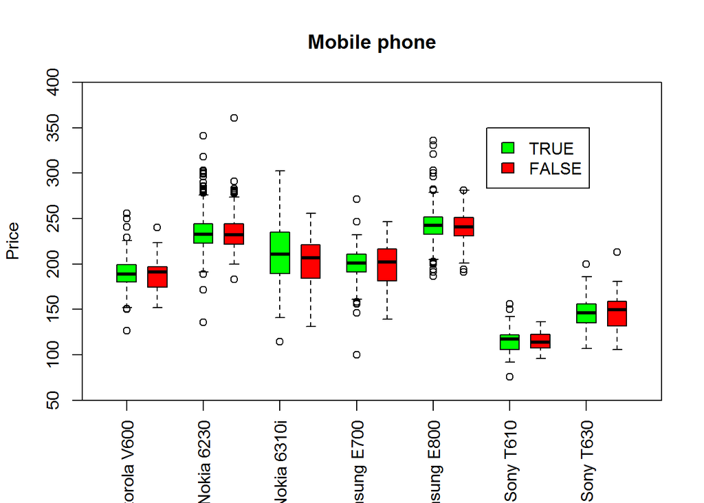

```r
# Variante 1 (basis plot):
boxplot(pricing$price ~ pricing$categorie,
        boxwex = 0.25, at = 1:7 - 0.2,
        data = pricing,
        subset = pricing$makellos == TRUE,
        main = "Mobile phone",
        col = "green",
        xlim = c(0.5, 7.5),
        ylim = c(50, 400),
        yaxs = "i",
        ylab = "Price",
        las=3,
        yaxt = "n"
        )
boxplot(pricing$price ~ pricing$categorie,
        boxwex = 0.25, at = 1:7 + 0.2,
        data = pricing,
        subset = pricing$makellos == FALSE,
        col = "red",
        add = TRUE,
        xaxt = "n"
        )
legend(5.5, 350, c("TRUE", "FALSE"),
       fill = c("green", "red")
       )
```

```r
# Dieser Code soll den Text Verkleinern, leider funktioniert das nicht im Markdown.
par(cex.axis=0.6)
```

- Plot der ersten Variante als PDF speichern mobil_v1.pdf

```r
pdf("mobil_v1.pdf")
boxplot(pricing$price ~ pricing$categorie,
        boxwex = 0.25, at = 1:7 - 0.2,
        data = pricing,
        subset = pricing$makellos == TRUE,
        main = "Mobile phone",
        col = "green",
        xlim = c(0.5, 7.5),
        ylim = c(50, 400),
        yaxs = "i",
        ylab = "Price",
        las=3,
        yaxt = "n"
        )
boxplot(pricing$price ~ pricing$categorie,
        boxwex = 0.25, at = 1:7 + 0.2,
        data = pricing,
        subset = pricing$makellos == FALSE,
        col = "red",
        add = TRUE,
        xaxt = "n"
        )
legend(5.5, 350, c("TRUE", "FALSE"),
       fill = c("green", "red")
       )
par(cex.axis=0.6)
dev.off()
```